# Utbildning och kompetensflöden

I detta kapitel ges en översikt över utbildningssystemet i Uppsala län, från gymnasiet till högre utbildning. Här ingår gymnasieskolan, Komvux och folkhögskolan samt eftergymnasiala utbildningar som yrkeshögskolan.

Syftet är att ge en övergripande bild av utbildningssystemet i Uppsala län och dess kommuner – från elevsammansättning och programval till övergångar mot arbetslivet.

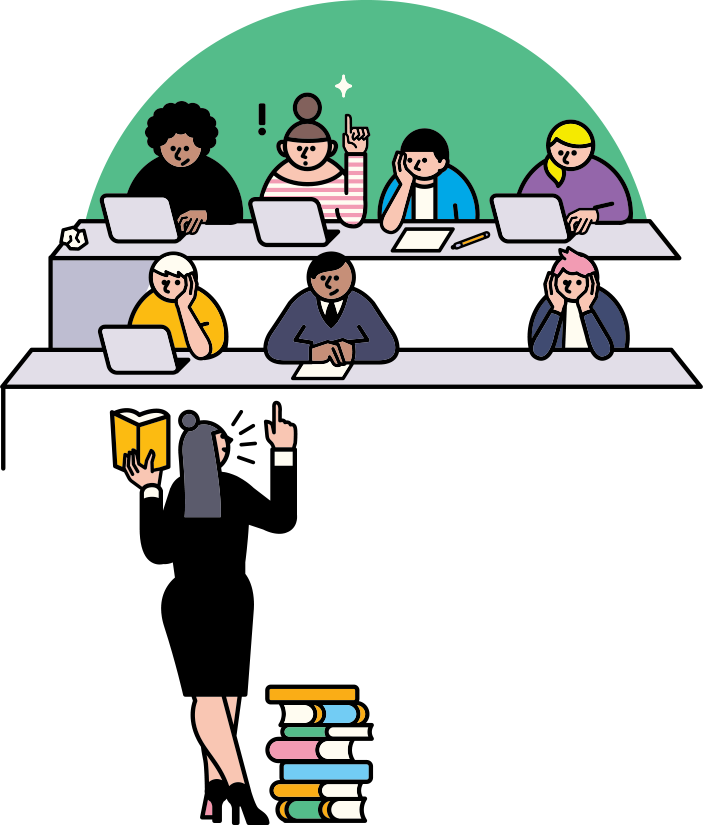

## Gymnasiet

I detta avsnitt redovisas statistik om gymnasieskolan i länet. Fokus ligger på andelen elever som läser högskoleförberedande respektive yrkesprogram, samt på könsfördelning och andra centrala elevfaktorer. Vidare belyses söktryck och beläggning inom olika program, liksom övergången till vidare studier och arbetsmarknaden.

[figure not shown]

Figur 1

Ladda ner

Som SVG Som PNG

Figur 1 visar andelen elever i yrkesprogram respektive högskoleförberedande program per skolkommun (skolort) i Uppsala län läsåret 2024/25. Uppgifterna är skolbaserade och avser var skolan är belägen, inte elevernas hemkommun. Heby och Älvkarleby saknar egna gymnasieskolor.

I de flesta kommuner går en större andel elever på högskoleförberedande program, medan Knivsta avviker genom att enbart erbjuda yrkesprogram. Andelen elever på yrkesprogram är relativt hög i Tierp och Östhammar jämfört med övriga kommuner.

Eftersom redovisningen är skolbaserad speglar statistiken i första hand programutbudet i respektive kommun. På länsnivå fångas i stort sett samtliga elever, med undantag för dem som pendlar över länsgränsen. I de mindre kommunerna återspeglar statistiken främst det lokala utbudet, eftersom många elever pendlar till andra kommuner för att läsa sitt valda program.

**Könsfördelning**

[figure not shown]

Figur 2

Ladda ner

Som SVG Som PNG

**Med utländsk bakgrund**

[figure not shown]

Figur 3

Ladda ner

Som SVG Som PNG

**Med högutbildade föräldrar**

[figure not shown]

Figur 4

Ladda ner

Som SVG Som PNG

#### Gymnasieelever med utländsk bakgrund

Figur 3 visar andelen gymnasieelever med utländsk bakgrund i Uppsala län läsåret 2024/25. I flera kommuner är andelen högre på de högskoleförberedande programmen än på yrkesprogrammen. I Uppsala, Enköping och Tierp ligger andelen runt 30 procent på de högskoleförberedande programmen och omkring 20 procent på yrkesprogrammen. I Håbo är andelarna ungefär lika mellan programtyperna. De lägsta andelarna återfinns i Östhammar, med cirka 11 procent på de högskoleförberedande programmen och 9 procent på yrkesprogrammen. I Knivsta erbjuds endast yrkesprogram, där andelen elever med utländsk bakgrund uppgår till cirka 50 procent.

#### Gymnasieelever med högutbildade föräldrar

Figur 4 visar andelen gymnasieelever i Uppsala län läsåret 2024/25 med högutbildade föräldrar. I samtliga kommuner är andelen högre på de högskoleförberedande programmen än på yrkesprogrammen. Skillnaderna mellan programtyperna är särskilt stora i Uppsala, Enköping, Håbo och Östhammar, där de uppgår till omkring 20–30 procentenheter, medan de är något mindre i Tierp.

### Avgång till eftergymnasial utbildning

[figure not shown]

Figur 5

Ladda ner

Som SVG Som PNG

Figur 5 visar andelen gymnasieexaminerade i Uppsala län som har påbörjat en eftergymnasial utbildning inom tre år efter avslutad gymnasieutbildning, uppdelat efter programtyp.

Andelen som går vidare till eftergymnasial utbildning är genomgående hög bland elever från högskoleförberedande program och ligger stabilt runt 75–80 procent under perioden. För samtliga gymnasieprogram sammantaget ligger andelen kring 60 procent, med en svag ökning fram till 2019.

Bland elever från yrkesprogram är övergången till eftergymnasial utbildning betydligt lägre, men visar en viss uppgång mot slutet av perioden. Utvecklingen speglar tydliga skillnader i utbildningsvägar efter gymnasiet, där högskoleförberedande program i större utsträckning leder vidare till fortsatta studier, medan yrkesprogram i högre grad är inriktade mot direkt etablering på arbetsmarknaden.

[figure not shown]

Figur 6

Ladda ner

Som SVG Som PNG

**NoteraVad är beläggning och söktryck – och vilka begränsningar har måtten?**

**Beläggning**: Andelen platser som förväntas bli fyllda utifrån antalet antagna. För att mäta faktisk beläggning krävs antalet inskrivna/registrerade – de som faktiskt påbörjar utbildningen.

$${Beläggningsgrad \ (\%)} = \frac{{Antagna}}{{Platser}} \times 100$$

**Söktryck**: Hur stor efterfrågan det finns jämfört med antalet platser.

$${Söktryck \ (\%)} = \frac{({Antagna} + {Reserver})}{{Platser}} \times 100$$

**Begränsningar**: Beläggning och söktryck ger en snabb bild av relationen mellan utbud och efterfrågan i gymnasieutbildningarna, men båda måtten har viktiga begränsningar att ha i åtanke. **Beläggning** som den beräknas här visar den **förväntade** beläggningen vid antagning – inte den **faktiska**. Vi vet alltså inte hur många antagna som faktiskt registrerar sig och påbörjar utbildningen (avhopp, sena omval, flytt m.m.).

**Söktryck** fångar efterfrågan bortom dem som antas. Men alla sökande hamnar inte på reservlistan; antagningssystemet prioriterar och begränsar hur många som får reservplats. Därför gäller söktryck ≠ sökande/platser. Ett högt söktryck kan drivas av popularitet, men också av begränsat platsutbud. Utan kontext (t.ex. kapacitet, behörighet, urvalskriterier) kan tolkningen därför bli missvisande.

Söktrycket 2024 (antagna + reserver / platser) (Figur 6) ligger över 100 procent i flera studievägar – tydligast i Hotell- och turismprogrammet (högst), följt av Ekonomiprogrammet, Samhällsvetenskapsprogrammet och El- och energiprogrammet. Dessa program är därmed översökta.

Runt balansnivån (100 procent) ligger bland annat VVS- och fastighetsprogrammet samt delar av hantverksprogrammet. Under 100 procent – där det kan finnas ledig kapacitet – återfinns bland annat Estetiska programmet, Vård- och omsorgsprogrammet, Bygg- och anläggningsprogrammet och Industritekniska programmet.

Sammantaget tyder detta på behov av fler platser eller ökad kapacitet inom de mest efterfrågade programmen, samt på behov av stärkt rekrytering eller justerad dimensionering inom program med lägre söktryck.

I följande avsnitt redovisas statistik för alla avgångselever som var bosatta i länet vid avgångsåret. Statistiken är inte uppdelad efter enskilda skolor.

[figure not shown]

Figur 7

Ladda ner

Som SVG Som PNG

Figur 7 visar antalet avgångselever från gymnasiet i Uppsala län. Sedan 2019 har antalet avgångselever från gymnasiet ökat något, från cirka 3 300 till 4 000 elever.

[figure not shown]

Figur 8

Ladda ner

Som SVG Som PNG

Över 70 procent av avgångseleverna i Uppsala län har läst ett högskoleförberedande program, medan resterande andel har gått ett yrkesprogram. Fördelningen har varit stabil under perioden 2019–2024

[figure not shown]

Figur 9

Ladda ner

Som SVG Som PNG

Andelen avgångselever med utländsk bakgrund har ökat något över tid, från 18 procent 2019 till 23 procent 2024. Efter en ökning fram till 2021 har andelen legat relativt stabilt, med en ny uppgång det senaste året.

### Tre år efter gymnasiet

I dashboarden nedan visas statistik för enskilda gymnasieprogram. Genom att välja program i rullistan kan du utforska utvecklingen för respektive program.

Statistiken för arbetsmarknadsstatus, matchning och inkomst baseras på ett aggregerat resultat från tre kohorter – elever som avslutade sin utbildning 2019, 2020 och 2021 – vilka följs upp tre år efter examen. Medianinkomst beräknas endast för de elever som är sysselsatta.

Viss statistik redovisas inte i de fall antalet elever understiger 10, vilket kan påverka redovisningen av exempelvis elevantal, könsfördelning och medianinkomst. Det bör även noteras att en individ kan vara registrerad både som sysselsatt och studerande.

Resultaten bör tolkas med viss försiktighet. Inkomststatistiken säger exempelvis inget om anställningarnas omfattning, såsom om arbetet är på hel- eller deltid. Medianinkomsten kan också påverkas av att grupperna i vissa fall är små och bör därför inte övertolkas. Samtidigt kan inkomsten ge en indikation på individernas etablering på arbetsmarknaden.

Med arbetsrelaterad inkomst avses inkomst från arbete och arbetsrelaterade ersättningar, såsom lön, näringsinkomst samt exempelvis sjuk- och föräldrapenning. Inkomsten är inflationsjusterad och redovisas i 2024 års prisnivå.

#### Gymnasieprogram

**Välj gymnasieprogram:**

#### Ekonomiprogrammet (EK)

Antal avgångselever per år

[figure not shown]

Arbetsmarknadsstatus tre år efter avslutad utbildning

Matchning

34%

Medianinkomst

21 000

## Folkhögskolan

I detta avsnitt redovisas statistik om folkhögskolorna i länet. I Uppsala län bedrivs folkhögskoleverksamhet på fyra orter: Wik, Uppsala, Tierp och Heby.

[figure not shown]

Figur 10

Ladda ner

Som SVG Som PNG

Figur 10 visar antalet deltagare i folkhögskolans kurser 2024, fördelat efter kursinriktning. De största inriktningarna är estetiska ämnen (417 deltagare), allmän, bred ämnesinriktning (354 deltagare) och beteendevetenskap/humaniora (313 deltagare).

Dessa tre områden utgör tillsammans majoriteten av kursutbudet vid folkhögskolorna i länet. Inriktningar som medicin, hälso- och sjukvård samt språk har ett mer begränsat deltagande, medan samhällsvetenskap är den minsta inriktningen med endast 40 deltagare.

**Könsfördelning**

[figure not shown]

Figur 11

Ladda ner

Som SVG Som PNG

**Åldersgrupper**

[figure not shown]

Figur 12

**Svensk vs utländsk bakgrund**

[figure not shown]

Figur 13

#### Könsfördelning

Alla kursinriktningar är kvinnodominerade. För allmän, bred ämnesinriktning och samhällsvetenskap är andelen män högst, omkring 40 procent. Inom kursinriktningarna estetiska ämnen, beteendevetenskap/humaniora samt språk ligger andelen män mellan 20 och 30 procent. Medicin, hälso- och sjukvård är den mest kvinnodominerade inriktningen, där andelen män uppgår till endast 6 procent.

#### Åldersgrupper

När vi ser till åldersfördelningen bland deltagarna i olika kursinriktningar inom folkhögskolan 2024 framgår det att majoriteten är mellan 20 och 44 år. Det finns också en relativt stor andel äldre deltagare, särskilt inom estetiska ämnen samt, i något mindre utsträckning, inom beteendevetenskap/humaniora, medicin, hälso- och sjukvård och samhällsvetenskap.

Bland deltagare i åldersgruppen 20–34 år är andelen högst inom allmän, bred ämnesinriktning och samhällsvetenskap. För den yngsta gruppen, under 17 år, är deltagandet störst inom allmän, bred ämnesinriktning.

#### Svensk vs utländsk bakgrund

När vi ser till andelen deltagare med utländsk bakgrund har nästan 24 procent av deltagarna utländsk bakgrund, medan 65 procent har svensk bakgrund. För 11 procent saknas uppgift om bakgrund.

## Komvux

Här redovisas statistik för deltagare inom Komvux som var bosatta i länet vid avslutad utbildning. Inom Komvux kan man läsa enskilda kurser eller ingå i ett yrkespaket. I detta avsnitt redovisas endast statistik för deltagare som läser ett yrkespaket.

[figure not shown]

Figur 14

Ladda ner

Som SVG Som PNG

Antalet deltagare som läser yrkespaket inom Komvux i Uppsala län har varierat de senaste fem åren. Under större delen av perioden har antalet legat mellan 1 300 och 1 650 deltagare.

[figure not shown]

Figur 15

Ladda ner

Som SVG Som PNG

Könsfördelningen per yrkespaket, aggregerad för perioden 2020–2024, visar tydliga skillnader mellan programmen. Yrkesområden som VVS och fastighet (VFX), el och energi (EEX), fordon och transport (FTX) samt bygg och anläggning är tydligt mansdominerade, där endast 12–22 procent av deltagarna är kvinnor.

Samtidigt finns program med en högre andel kvinnor, mellan 60 och 90 procent. Dessa inkluderar hotell och turism (HTX), restaurang och livsmedel (RLX), barn och fritid (BFX), vård och omsorg (VOX) samt hantverk (HVX).

[figure not shown]

Figur 16

Ladda ner

Som SVG Som PNG

En stor andel av deltagarna som läser yrkespaket inom Komvux i Uppsala län har utländsk bakgrund. I många program överstiger andelen 70 procent, till exempel inom vård och omsorg (VOX), barn och fritid (BFX) samt restaurang och livsmedel (RLX).

Andelen med utländsk bakgrund är lägre, omkring 40–50 procent, inom fordon och transport (FTX), el och energi (EEX), hantverk (HVX) samt VVS och fastighet (VFX).

### Ett år efter Komvux

I dashboarden nedan visas statistik för yrkespaket inom Komvux. Genom att välja yrkespaket i rullistan kan du utforska utvecklingen för respektive utbildning.

Diagrammet överst visar antalet deltagare över tid, medan diagrammet nedanför visar arbetsmarknadsstatus ett år efter avslutad utbildning. Nyckeltalen till höger redovisar matchning och medianinkomst.

Statistiken för arbetsmarknadsstatus, matchning och inkomst baseras på ett aggregerat resultat från åtta kohorter – deltagare som avslutade sin utbildning under åren 2020–2023, vid både vår- och hösttermin. Till skillnad från gymnasiestatistiken registreras inte när deltagare avslutar sin utbildning inom Komvux. I denna analys antas därför att en deltagare har avslutat sin utbildning om hen inte har läst några kurser under det efterföljande året. Medianinkomst beräknas endast för de deltagare som är sysselsatta.

Viss statistik redovisas inte i de fall antalet deltagare understiger 10, vilket kan påverka redovisningen av exempelvis antal deltagare och medianinkomst. Det bör även noteras att en individ kan vara registrerad både som sysselsatt och studerande.

Resultaten bör tolkas med viss försiktighet. Inkomststatistiken säger exempelvis inget om anställningarnas omfattning, såsom om arbetet är på hel- eller deltid. Medianinkomsten kan också påverkas av att grupperna i vissa fall är små och bör därför inte övertolkas. Samtidigt kan inkomsten ge en indikation på individernas etablering på arbetsmarknaden.

Med arbetsrelaterad inkomst avses inkomst från arbete och arbetsrelaterade ersättningar, såsom lön, näringsinkomst samt exempelvis sjuk- och föräldrapenning. Inkomsten är inflationsjusterad och redovisas i 2024 års prisnivå.

#### Yrkespaket

**Välj yrkespaket:**

#### Yrkespaket vård och omsorg, VOX

Yrkespaket inom vård och omsorg: Antal elever

[figure not shown]

Arbetsmarknadsstatus ett år efter avslutad utbildning

Matchning

40%

Medianinkomst

29 500

## Yrkeshögskolan

Figuren nedan visar antalet antagna till yrkeshögskolan i Uppsala län, baserat på den region där utbildningen bedrivs.

[figure not shown]

Figur 17

Ladda ner

Som SVG Som PNG

Figur 17 visar en ökning av antalet antagna mellan 2023 och 2024, med omkring 40 fler antagna 2024. Antagningen domineras av kvinnor, som utgör cirka 75–80 procent av de antagna.

[figure not shown]

Figur 18

Ladda ner

Som SVG Som PNG

Figur 18 visar antalet antagna till yrkeshögskolan i Uppsala län 2024, uppdelat efter utbildningsgrupp och kön. Antagningen är störst inom teknikutbildningar, tandsköterskeutbildningar, data- och IT-utbildningar samt utbildningar inom vård och omsorg.

För flera utbildningsgrupper dominerar kvinnor tydligt, särskilt inom vård- och omsorgsutbildningar, där samtliga antagna är kvinnor. Även inom teknikutbildningar samt utbildningar inom lant- och skogsbruk utgör kvinnor en stor andel av de antagna. Inom data- och IT-utbildningar är män däremot i majoritet. För journalistik- och medievetenskapliga utbildningar är könsfördelningen relativt jämn, med en något större andel män. Figuren visar därmed en tydligt könssegregerad utbildningsstruktur inom yrkeshögskolan.

Följande statistik avser YH-studerande som är folkbokförda i Uppsala län. Uppgifterna redovisas efter hemkommun, inte efter var utbildningen bedrivs. Utbildningar med färre än 10 studerande redovisas inte av sekretesskäl. Det innebär att vissa utbildningsområden kan finnas, men inte visas i statistiken.

[figure not shown]

Figur 19

Ladda ner

Som SVG Som PNG

Figur 19 visar andelen YH-studerande som studerar i respektive utanför länet. En tydlig majoritet av de studerande återfinns utanför länet inom samtliga utbildningsområden. Samtidigt finns vissa skillnader mellan områdena. Hälso- och sjukvård samt socialt arbete utmärker sig med den högsta andelen studerande i länet, medan övriga utbildningsområden i ännu högre grad domineras av studier utanför länet. Inom flera områden, såsom transporttjänster, säkerhetstjänster, pedagogik och undervisning samt kultur, media och design, sker i princip all utbildning utanför länet.

För att ge en bild av utbildningsformen bland de studerande som läser utanför länet visar Figur 20 andelen av dessa som studerar på distans.

[figure not shown]

Figur 20

Ladda ner

Som SVG Som PNG

För de flesta utbildningsområden är majoriteten av de som studerar utanför länet distansstuderande. Andelen varierar dock mellan områdena och är särskilt hög inom hälso- och sjukvård, socialt arbete samt pedagogik och undervisning. Samtidigt är andelen lägre inom exempelvis kultur, media och design samt data och IT.

[figure not shown]

Figur 21

Ladda ner

Som SVG Som PNG

Figur 21 visar andelen som examineras, där endast studerande som har fått slutbetyg ingår. Examensandelen är genomgående relativt hög inom samtliga utbildningsområden, men varierar något mellan dem. Högst andel återfinns inom kultur, media och design samt lantbruk, djurvård, trädgård, skog och fiske. Även ekonomi, administration och försäljning samt hotell, restaurang och turism uppvisar höga examensnivåer. Lägst examensandel ses inom teknik och tillverkning, följt av samhällsbyggnad och byggteknik, även om nivåerna fortsatt är förhållandevis höga.

Följande statistik visar antalet studerande per utbildningsområde, uppdelat efter kommun. Statistiken omfattar samtliga studerande, oavsett studieår.

**Uppsala**

[figure not shown]

Figur 22

Ladda ner

Som SVG Som PNG

**Enköping**

[figure not shown]

Figur 23

Ladda ner

Som SVG Som PNG

**Knivsta**

[figure not shown]

Figur 24

Ladda ner

Som SVG Som PNG

**Östhammar**

[figure not shown]

Figur 25

Ladda ner

Som SVG Som PNG

**Tierp**

[figure not shown]

Figur 26

Ladda ner

Som SVG Som PNG

**Heby**

[figure not shown]

Figur 27

Ladda ner

Som SVG Som PNG

**Håbo**

[figure not shown]

Figur 28

Ladda ner

Som SVG Som PNG

**Älvkarleby**

[figure not shown]

Figur 29

Ladda ner

Som SVG Som PNG

💬

**Vid frågor kontakta**  
Region Uppsala - Regional Utveckling  
regionalutveckling.analys@regionuppsala.se